# Exploring water quality

Nicolas F. S-Gelais

2018-05-07

### Read files

Import the canadian rivers dataset data on stations and the canadian guidelines

```r
library(knitr)
library(kableExtra)
library(ReporteRs)
library(maps)
library(fmsb)
library(ggplot2)
library(tidyr)
rm(list=ls(all=TRUE))
source("R/functions.R")
load("data/dataCDN.RData")
load("data/sitesClassfc.RData")
load("data/critLimdoc.RData")
colFreq<-function(x)sum(!is.na(x))/length(x)
```

### 1. Compare ecoservices guidelines

In this table, we compare the proportion of guidelines in each group (columns) that are used for each ecoservice (rows). For irrigation and livestock, most guidelines are for pesticides and metals, while for drinking and aquatic wildlife, most guidelines are for pesticides and organic chemicals. For recreational activities guidelines are biollogical, physical and ph, while for trophic state guidelines are mostly for inorganic chemicals (i.e. nutrients).

(add a venn diagram for guidelines overlap?)

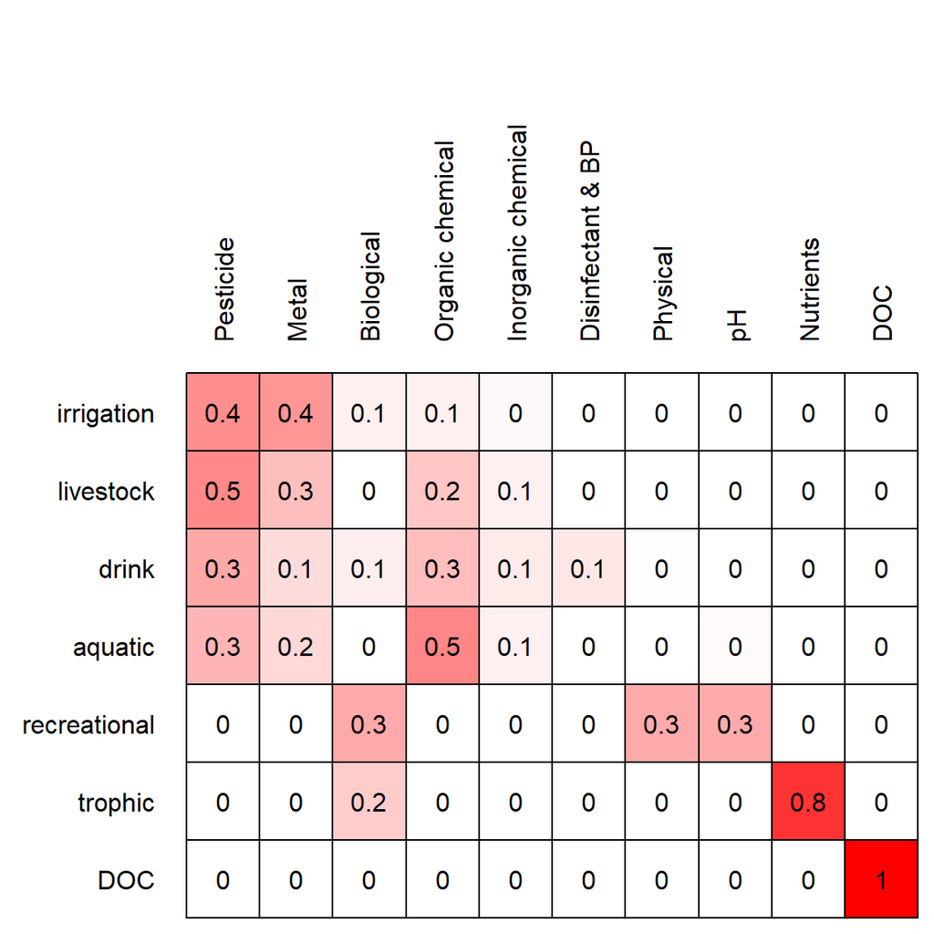

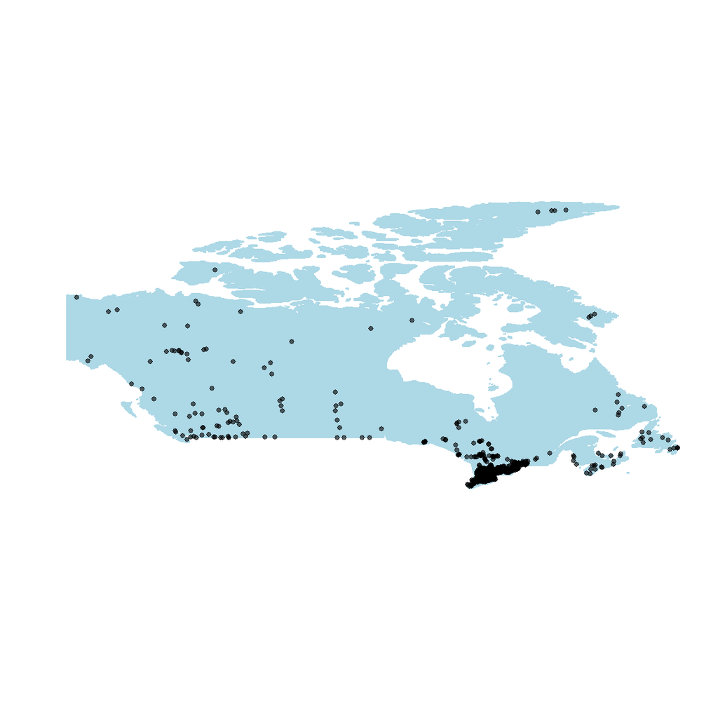

```
## [1] 0.08627159
```

|  | freq | Chemical.groups | aquatic | drink | irrigation | livestock | mesotrophic | oligotrophic | recreational |
| --- | --- | --- | --- | --- | --- | --- | --- | --- | --- |
| fc | 8.63 | Biological | NA | 11 | 100 | NA | NA | NA | 200 |
| chloride | 76.78 | Inorganic chemical | 120000 | NA | NA | NA | NA | NA | NA |
| fluoride | 15.51 | Inorganic chemical | 120 | 1500 | 1000 | NA | NA | NA | NA |
| nitrate | 73.65 | Inorganic chemical | 13000 | 45000 | NA | NA | NA | NA | NA |
| nitrite | 80.73 | Inorganic chemical | 11820 | 3000 | NA | 10000 | NA | NA | NA |
| arsenic | 23.99 | Metal | 5 | 10 | 100 | 25 | NA | NA | NA |
| cadmium | 60.02 | Metal | 0.09 | 5 | 5.1 | 80 | NA | NA | NA |
| copper | 75.98 | Metal | 2 | NA | NA | NA | NA | NA | NA |
| iron | 77.20 | Metal | 300 | NA | 5000 | NA | NA | NA | NA |
| lead | 48.54 | Metal | 1 | 10 | 200 | 100 | NA | NA | NA |
| molybdenum | 59.11 | Metal | 73 | NA | NA | 500 | NA | NA | NA |
| nickel | 62.00 | Metal | 25 | NA | 200 | 1000 | NA | NA | NA |
| uranium | 25.82 | Metal | 15 | 20 | 10 | 200 | NA | NA | NA |
| zinc | 75.33 | Metal | 30 | NA | NA | 50000 | NA | NA | NA |
| tn | 28.42 | Nutrients | NA | NA | NA | NA | 1500 | 700 | NA |
| tp | 96.10 | Nutrients | NA | NA | NA | NA | 75 | 25 | NA |
| toluene | 0.36 | Organic chemical | 2 | 60 | NA | 24 | NA | NA | NA |
| atrazine | 0.01 | Pesticide | 1.8 | 5 | 10 | 5 | NA | NA | NA |
| bromoxynil | 0.00 | Pesticide | 5 | 5 | 0.33 | 11 | NA | NA | NA |
| dicamba | 0.00 | Pesticide | 10 | 120 | 0.006 | 122 | NA | NA | NA |
| metolachlor | 0.12 | Pesticide | 7.8 | 50 | 28 | 50 | NA | NA | NA |
| simazine | 0.11 | Pesticide | 10 | 10 | 0.5 | 10 | NA | NA | NA |

### 2.Compare ecoservices in the dataset

In this table, we compare the occurence of the different ecoservices in the dataset. On the diagonal of this table, the proportion of sites for which a given criteria was met is reported. Outside the diagonal we are reporting how often the column criteria is met when the row criteria is met.

|  | oligotrophic | mesotrophic | eutrophic | aquatic | recreational | drink | irrigation | livestock |
| --- | --- | --- | --- | --- | --- | --- | --- | --- |
| oligotrophic | 0.32 | 0.00 | 0.00 | 0.29 | 0.85 | 0.25 | 0.71 | 1 |
| mesotrophic | 0.00 | 0.39 | 0.00 | 0.20 | 0.69 | 0.14 | 0.52 | 1 |
| eutrophic | 0.00 | 0.00 | 0.18 | 0.09 | 0.31 | 0.05 | 0.22 | 1 |
| aquatic | 0.44 | 0.37 | 0.08 | 0.22 | 0.81 | 0.22 | 0.66 | 1 |
| recreational | 0.41 | 0.40 | 0.08 | 0.26 | 0.66 | 0.23 | 0.78 | 1 |
| drink | 0.52 | 0.36 | 0.05 | 0.30 | 1.00 | 0.15 | 1.00 | 1 |
| irrigation | 0.44 | 0.39 | 0.07 | 0.27 | 1.00 | 0.30 | 0.51 | 1 |
| livestock | 0.33 | 0.39 | 0.18 | 0.22 | 0.67 | 0.16 | 0.52 | 1 |

In this dataset, 32 % of sites were oligotrophic, 39 % mesotrophic and 18% eutrophic. Only 22% of the samples were suitable for aquatic life, 66% for swimming and 15% for drinking. For gricultural use, in 51% of the samples the water was usable for irrigation and 100% for livestock.

When the water is oligotrophic are more often suitable for aquatic life (29%), recreation (85%), drinking (25%) and irrigation (71%) than mesotrpohic and eutrophic samples.

```
##        [,1]
## red   0.116
## green 0.828
## blue  0.116
```

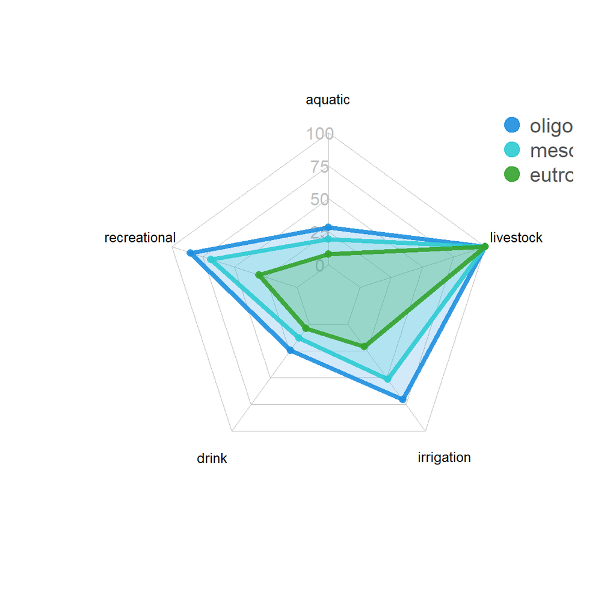

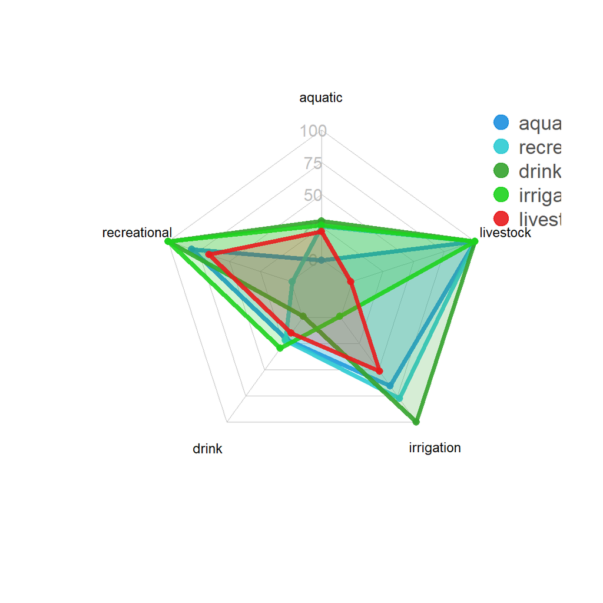

#### Ecoservices PCA

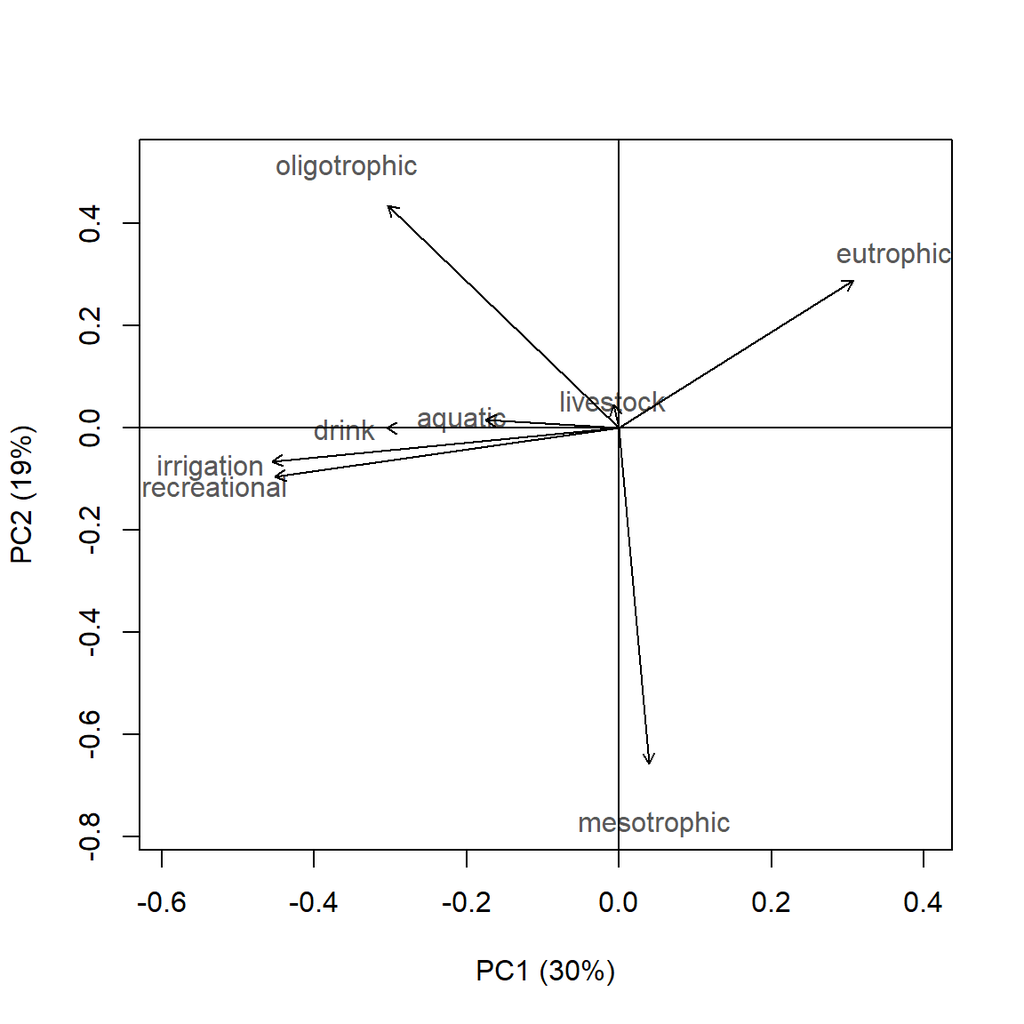

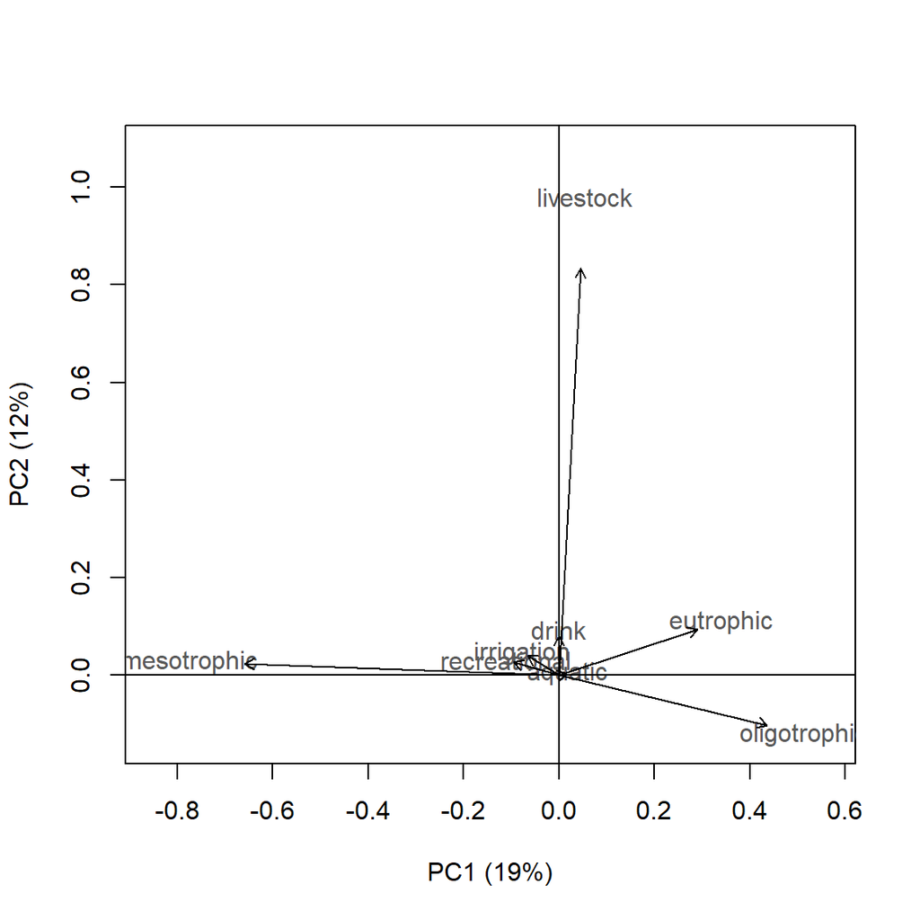

#### Comparing the limiting guidelines

In this table we compare the limiting guidelines for each ecoservice. For each guideline, we report how often when a sample cannot provide an ecoservice a specific guideline responsible for the none compliance. For trophic status, when a sample change from one trophic status to the other, TN and TP are almost always both over the guideline (Even if TP was measure more often)

|  | aquatic |
| --- | --- |
| cadmium | 0.65 |
| fluoride | 0.53 |
| iron | 0.48 |
| copper | 0.43 |
| lead | 0.43 |
| chloride | 0.18 |
| arsenic | 0.06 |
| zinc | 0.04 |
| nickel | 0.03 |
| metolachlor | 0 |
| molybdenum | 0 |
| nitrate | 0 |
| nitrite | 0 |
| simazine | 0 |
| uranium | 0 |

|  | irrigation |
| --- | --- |
| fc | 1 |
| iron | 0.74 |
| nickel | 0.13 |
| uranium | 0.1 |
| cadmium | 0.05 |
| lead | 0.01 |
| arsenic | 0 |
| fluoride | 0 |
| metolachlor | 0 |
| simazine | 0 |

|  | recreational |
| --- | --- |
| fc | 1 |
| turbidity | 0.99 |

|  | drink |
| --- | --- |
| turbidity | 1 |
| fc | 0.94 |
| lead | 0.02 |
| arsenic | 0 |
| cadmium | 0 |
| fluoride | 0 |
| metolachlor | 0 |
| nitrate | 0 |
| nitrite | 0 |
| simazine | 0 |
| uranium | 0 |

|  | eutrophic |
| --- | --- |
| tp | 0.97 |
| tn | 0.86 |

|  | mesotrophic |
| --- | --- |
| tn | 0.91 |
| tp | 0.91 |

|  | oligotrophic |
| --- | --- |
| tp | 0.9 |
| tn | 0.67 |

|  | livestock |
| --- | --- |
| lead | 0.78 |
| arsenic | 0.45 |
| cadmium | 0.06 |
| molybdenum | 0 |
| nickel | 0 |
| nitrite | 0 |
| uranium | 0 |
| zinc | 0 |

|  | DOC |
| --- | --- |
| doc | 1 |